# Cotton

Dr. Emily Burchfield

## Bright spots analysis

### Full panel overview

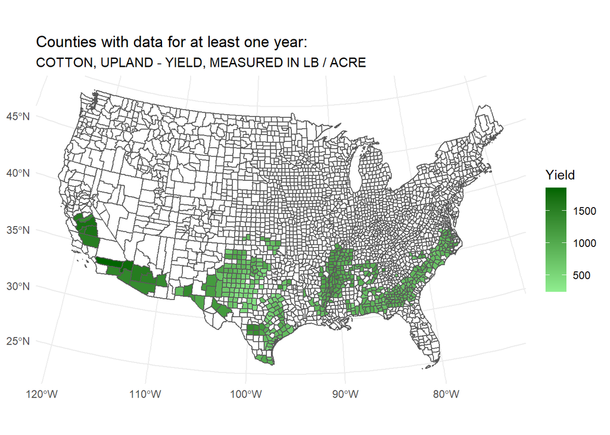

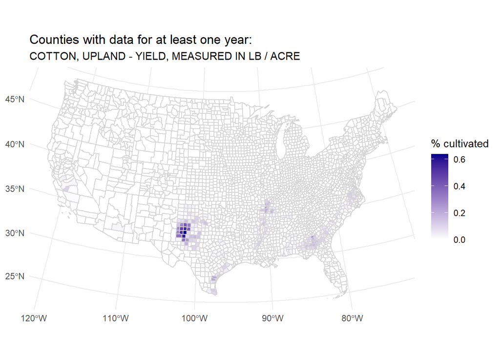

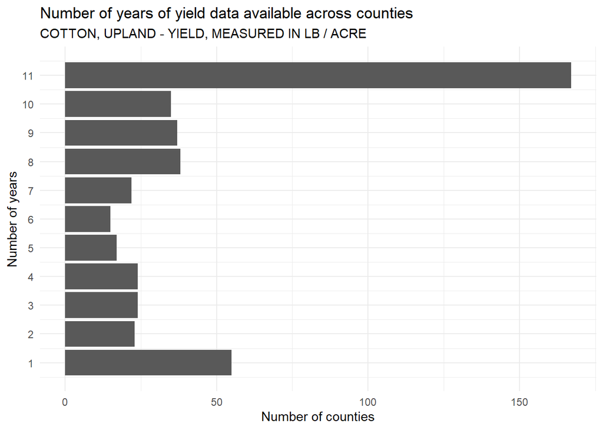

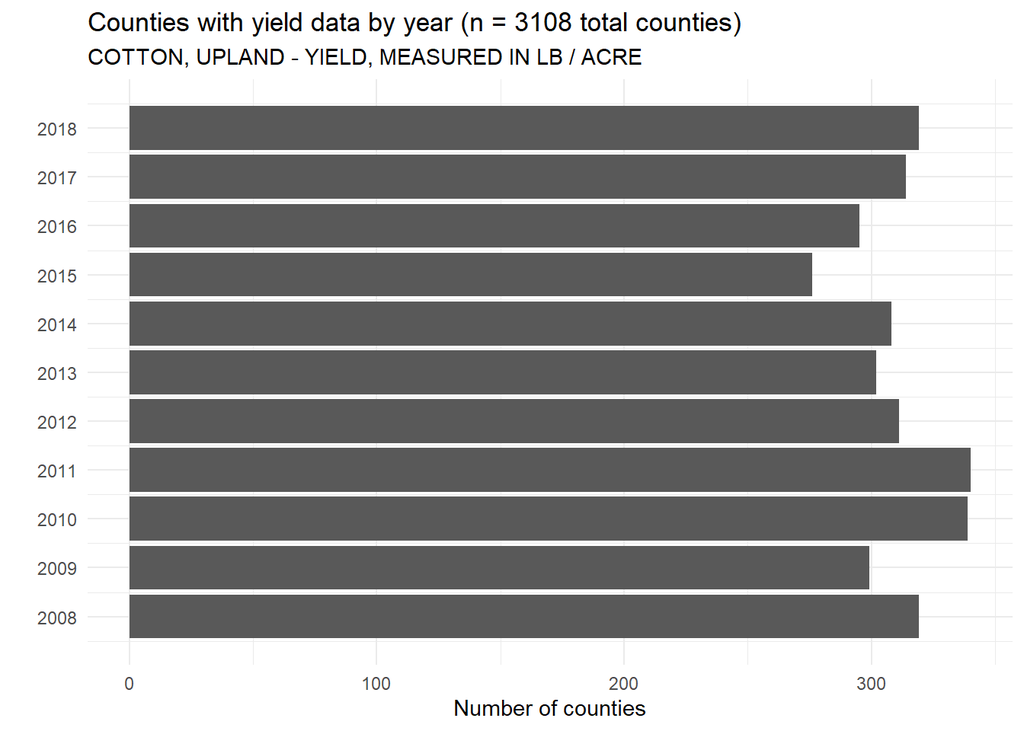

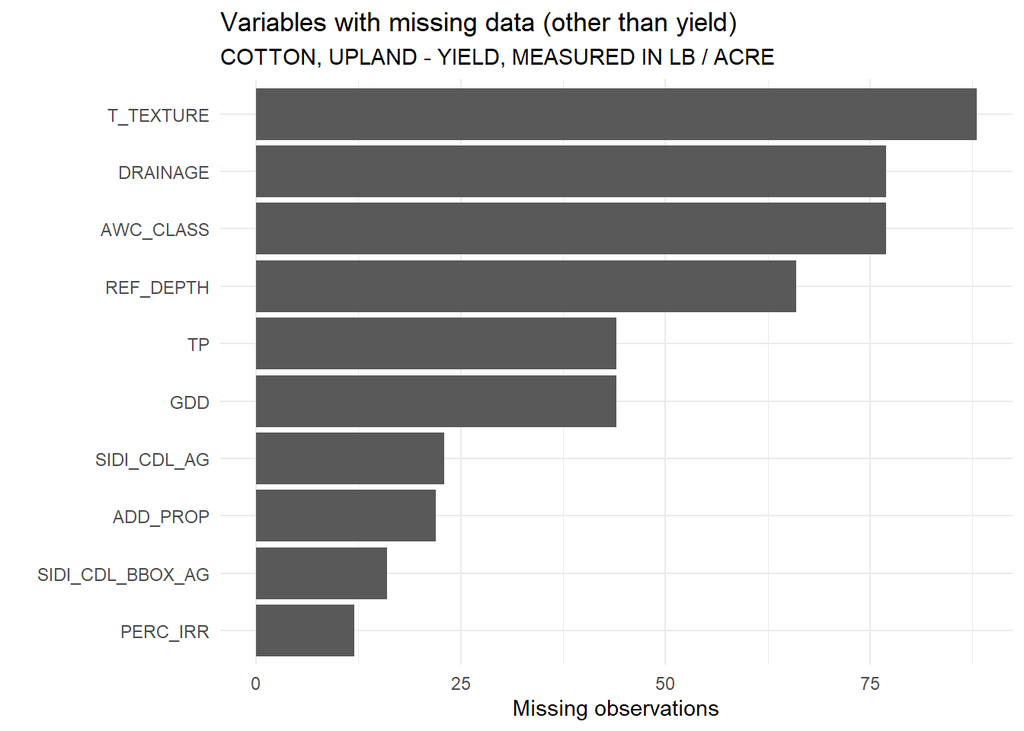

Notes on missing data:

- PRISM data is missing for the following counties due to a data corruption issue in the original PRISM data: `51600, 51610, 51678, 51685`
- `SIDI_CDL*_AG` columns are missing data in a few counties; likely due to the mask.

### Final panel overview

For the final panels, I have dropped rows with any missing data, eliminated FRRs with fewer than 10 counties, and selected only key variables. See `BS_sensitivity_testing.html` for an overview of the variable selection process.

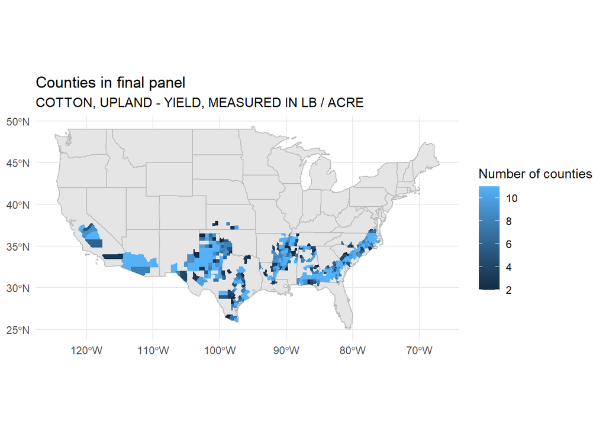

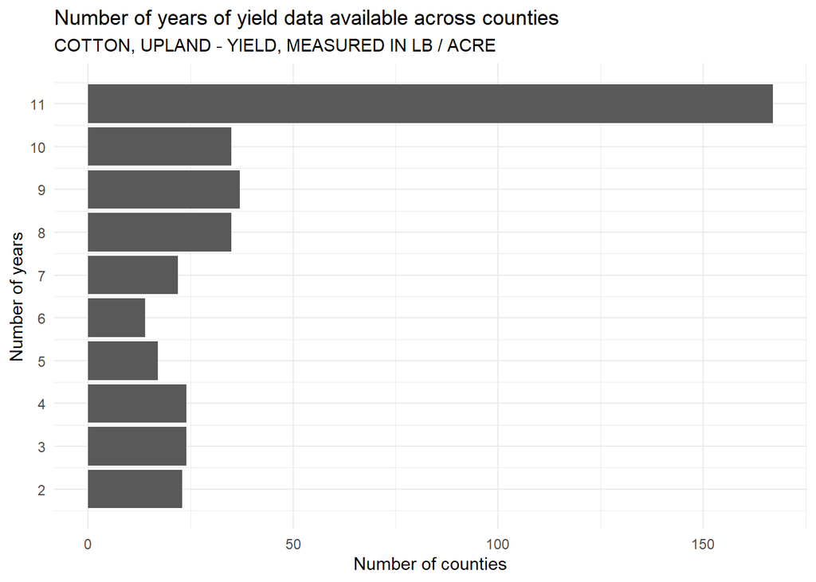

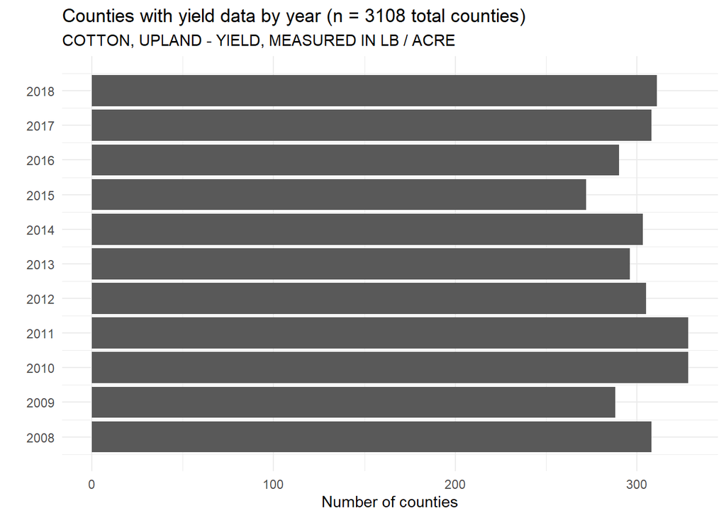

[figure not shown]

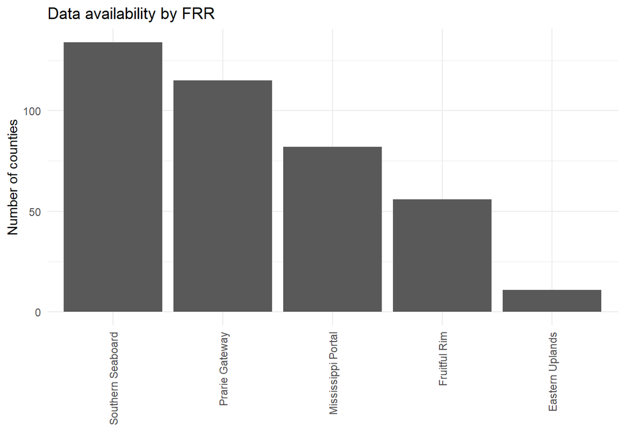

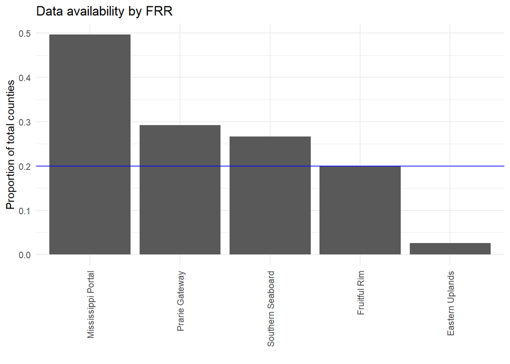

```
## [1] "Excluded FRRs are: "
```

```
## [1] Heartland             Northern Crescent     Northern Great Plains Basin and Range
## 9 Levels: Basin and Range Eastern Uplands Fruitful Rim Heartland Mississippi Portal Northern Crescent ... Southern Seaboard
```

| FRR_ID | FRR_NAME | COUNTY_AV | COUNTY_TOTAL | PERC_AV |
| --- | --- | --- | --- | --- |
| 4 | Prarie Gateway | 115 | 394 | 0.2918782 |
| 5 | Eastern Uplands | 11 | 421 | 0.0261283 |
| 6 | Southern Seaboard | 134 | 503 | 0.2664016 |
| 7 | Fruitful Rim | 56 | 280 | 0.2000000 |
| 9 | Mississippi Portal | 82 | 165 | 0.4969697 |

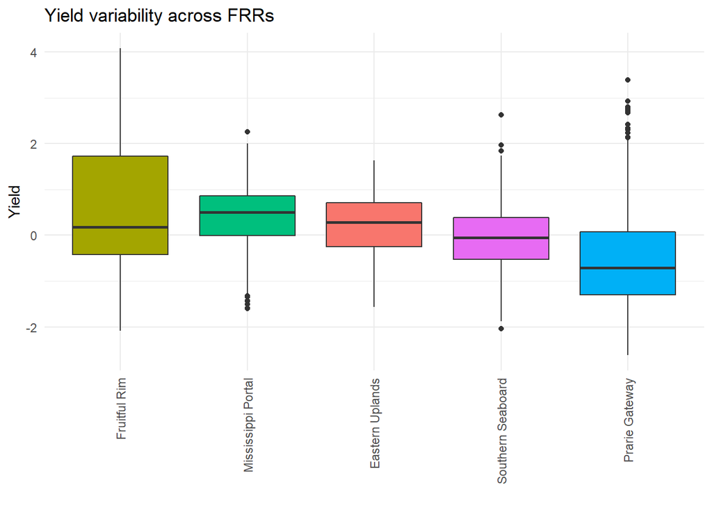

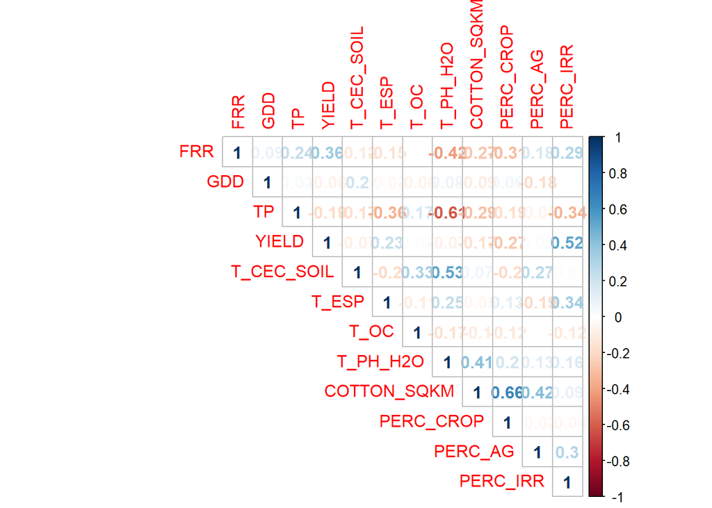

Here are the variables that still have a correlation above `0.5` (or below `-0.5`):

Variable pairs with high correlation

| Var1 | Var2 | Freq |
| --- | --- | --- |
| PERC_CROP | COTTON_SQKM | 0.66 |
| COTTON_SQKM | PERC_CROP | 0.66 |
| T_PH_H2O | TP | -0.61 |
| TP | T_PH_H2O | -0.61 |
| T_PH_H2O | T_CEC_SOIL | 0.53 |
| T_CEC_SOIL | T_PH_H2O | 0.53 |
| PERC_IRR | YIELD | 0.52 |
| YIELD | PERC_IRR | 0.52 |

And for reference, here is the adjacency structure used in the models:

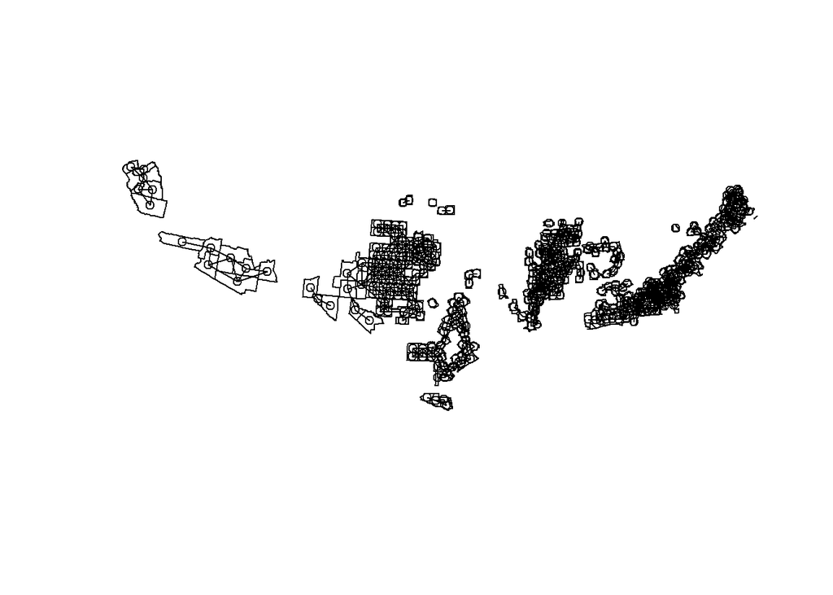

### Model specification

```r
  out <- prep_data(crop)
  null <- out[[1]]
  county_sub <- out[[2]]
  hadj <- build_adj_matrix(county_sub)

  null <- null %>% mutate_at(c("GDD", "TP"), ~inla.group(., n = 20, method = "quantile"))
  u <- sd(null$YIELD, na.rm = T)

  apar <- 0.5
  lmod <- lm(YIELD ~ GDD + TP  + T_CEC_SOIL + T_OC + T_PH_H2O + T_ESP +
               PERC_IRR +
               factor(YEAR), data=  null)
  bpar <- apar*var(residuals(lmod))
  lgprior <- list(prec = list(prior = "loggamma", param = c(apar, bpar)))

  formula <- YIELD ~ 1 +
    f(ID, model="bym2",
      graph=hadj,
      scale.model=TRUE,
      constr = TRUE) +
    f(FRR, model = "iid", hyper = lgprior) +
    f(GDD, model = "rw2",
      scale.model = T,
      hyper = list(theta = list(prior = "pc.prec",
                                param = c(u, 0.01)))) +
    f(TP, model = "rw2",
      scale.model = T,
      hyper = list(theta = list(prior = "pc.prec",
                                param = c(u, 0.01)))) +
    PERC_IRR +
    T_CEC_SOIL + T_OC + T_PH_H2O + T_ESP +
    factor(YEAR)

  mf <- inla(formula, data=null, family="gaussian",
             control.predictor = list(compute=T),
             control.compute = list(dic=T, cpo=T))
  df <- model_diagnostics(mf, null)
```

### Model results

Remember that variables have been *scaled* prior to running the analysis.

```
##
## Call:
##    c("inla(formula = formula, family = \"gaussian\", data = null, control.compute = list(dic = T, ", " cpo = T),
##    control.predictor = list(compute = T))")
## Time used:
##     Pre = 14.4, Running = 14.3, Post = 0.644, Total = 29.3
## Fixed effects:
##                    mean    sd 0.025quant 0.5quant 0.975quant   mode kld
## (Intercept)      -0.103 0.301     -0.705   -0.104      0.503 -0.105   0
## PERC_IRR          0.415 0.036      0.344    0.415      0.486  0.416   0
## T_CEC_SOIL        0.118 0.043      0.034    0.117      0.202  0.117   0
## T_OC             -0.014 0.031     -0.075   -0.014      0.047 -0.014   0
## T_PH_H2O         -0.052 0.061     -0.171   -0.052      0.068 -0.052   0
## T_ESP             0.074 0.034      0.006    0.074      0.141  0.074   0
## factor(YEAR)2009  0.115 0.046      0.025    0.115      0.205  0.115   0
## factor(YEAR)2010  0.145 0.046      0.054    0.145      0.235  0.145   0
## factor(YEAR)2011 -0.179 0.048     -0.273   -0.179     -0.085 -0.179   0
## factor(YEAR)2012  0.542 0.047      0.450    0.542      0.633  0.542   0
## factor(YEAR)2013  0.210 0.045      0.122    0.210      0.297  0.210   0
## factor(YEAR)2014  0.433 0.044      0.346    0.433      0.520  0.433   0
## factor(YEAR)2015  0.255 0.050      0.156    0.255      0.354  0.255   0
## factor(YEAR)2016  0.484 0.050      0.386    0.484      0.581  0.484   0
## factor(YEAR)2017  0.522 0.047      0.430    0.522      0.614  0.522   0
## factor(YEAR)2018  0.537 0.053      0.434    0.537      0.640  0.537   0
##
## Random effects:
##   Name     Model
##     ID BYM2 model
##    FRR IID model
##    GDD RW2 model
##    TP RW2 model
##
## Model hyperparameters:
##                                           mean     sd 0.025quant 0.5quant 0.975quant   mode
## Precision for the Gaussian observations  3.502  0.093      3.321     3.50      3.688  3.500
## Precision for ID                         4.276  0.451      3.448     4.26      5.220  4.223
## Phi for ID                               0.598  0.074      0.448     0.60      0.736  0.604
## Precision for FRR                        3.212  2.089      0.661     2.75      8.539  1.772
## Precision for GDD                       15.551 19.250      1.882     9.79     64.537  4.591
## Precision for TP                        20.002 11.436      5.795    17.47     49.008 13.066
##
## Expected number of effective parameters(stdev): 341.66(6.79)
## Number of equivalent replicates : 9.77
##
## Deviance Information Criterion (DIC) ...............: 5636.74
## Deviance Information Criterion (DIC, saturated) ....: 3686.75
## Effective number of parameters .....................: 344.81
##
## Marginal log-Likelihood:  -3044.22
## CPO and PIT are computed
##
## Posterior marginals for the linear predictor and
##  the fitted values are computed
```

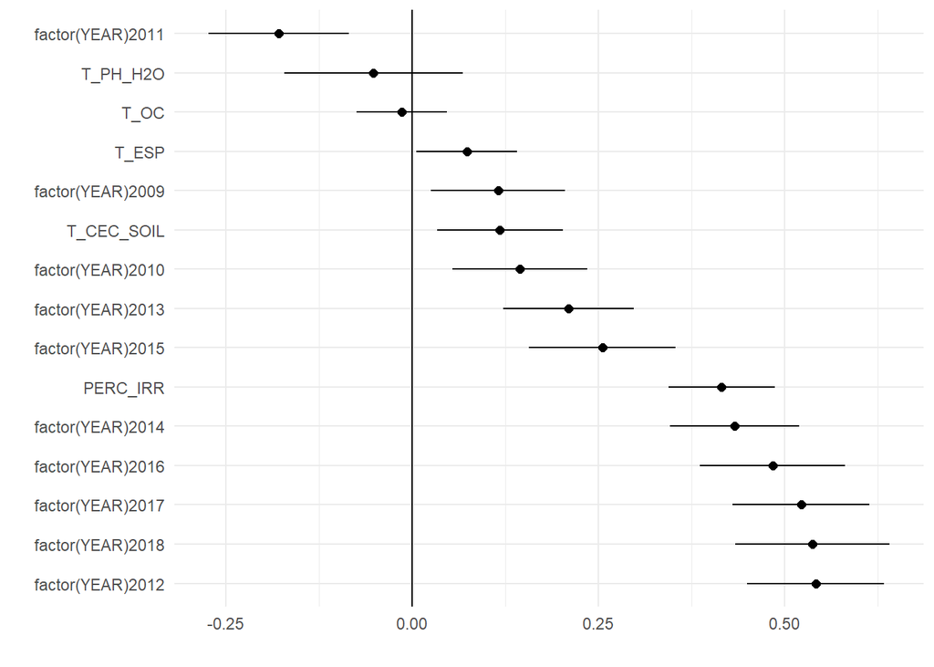

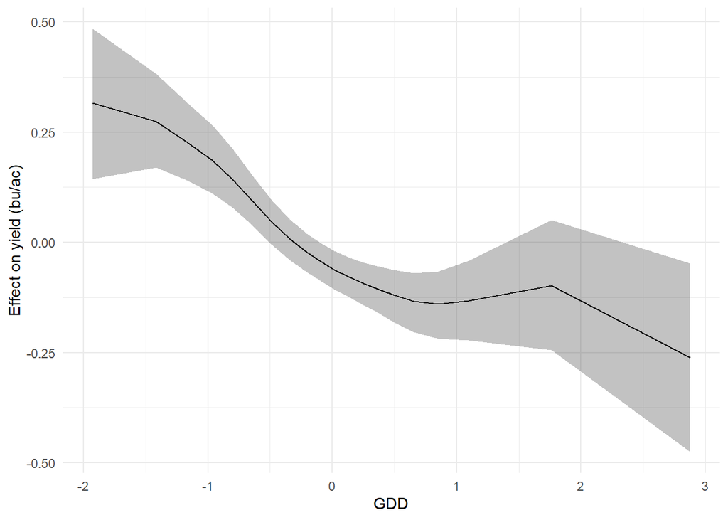

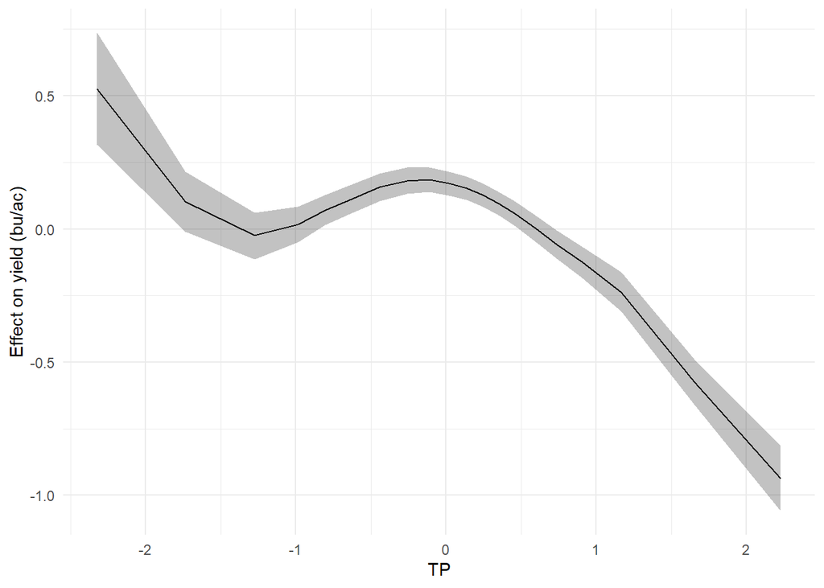

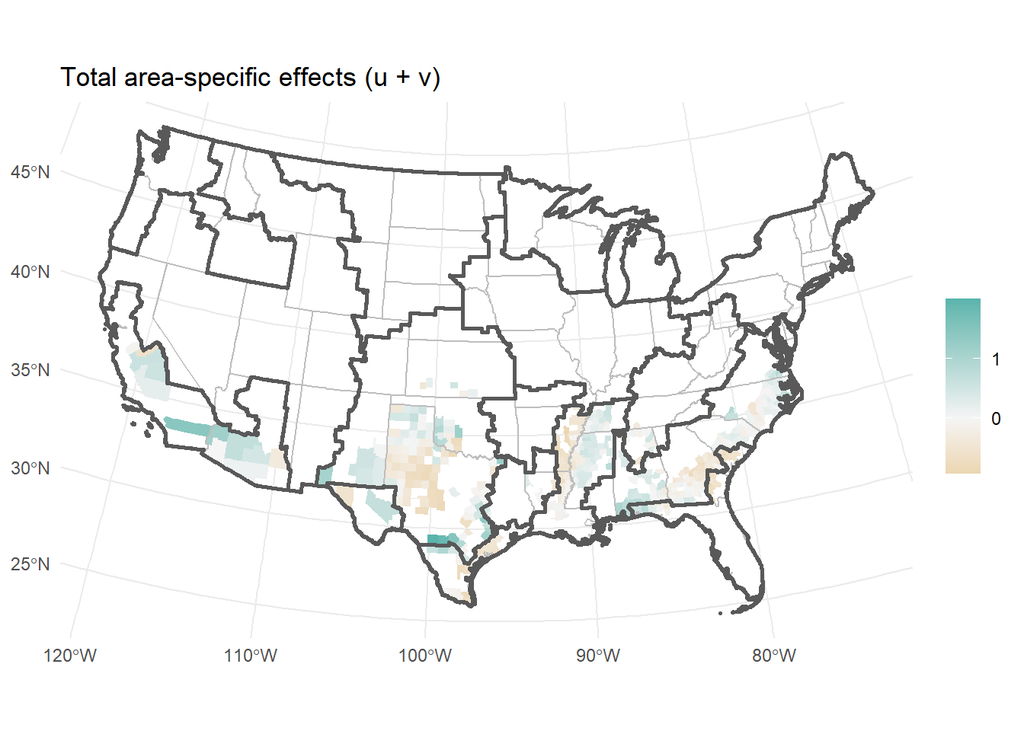

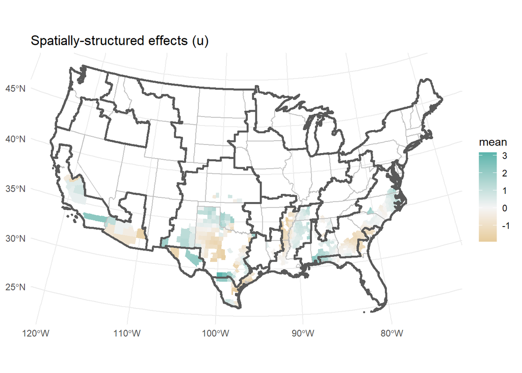

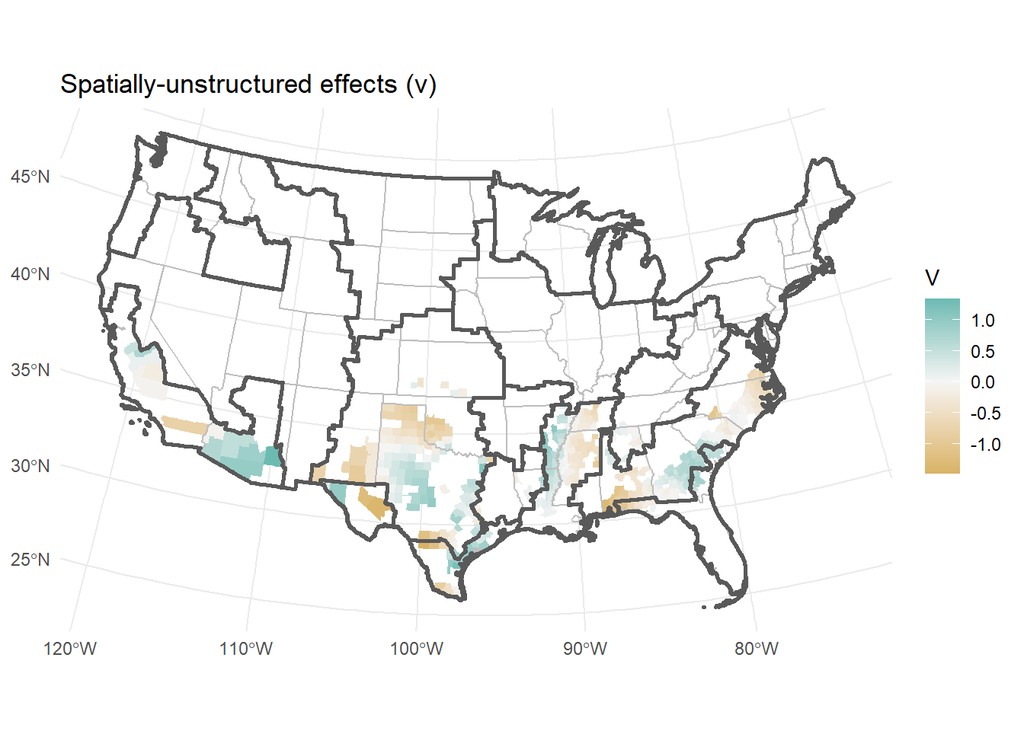

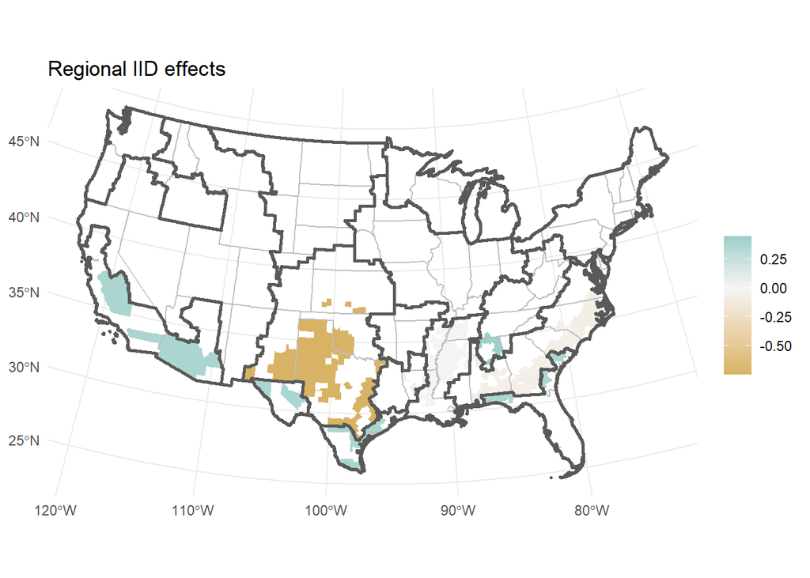

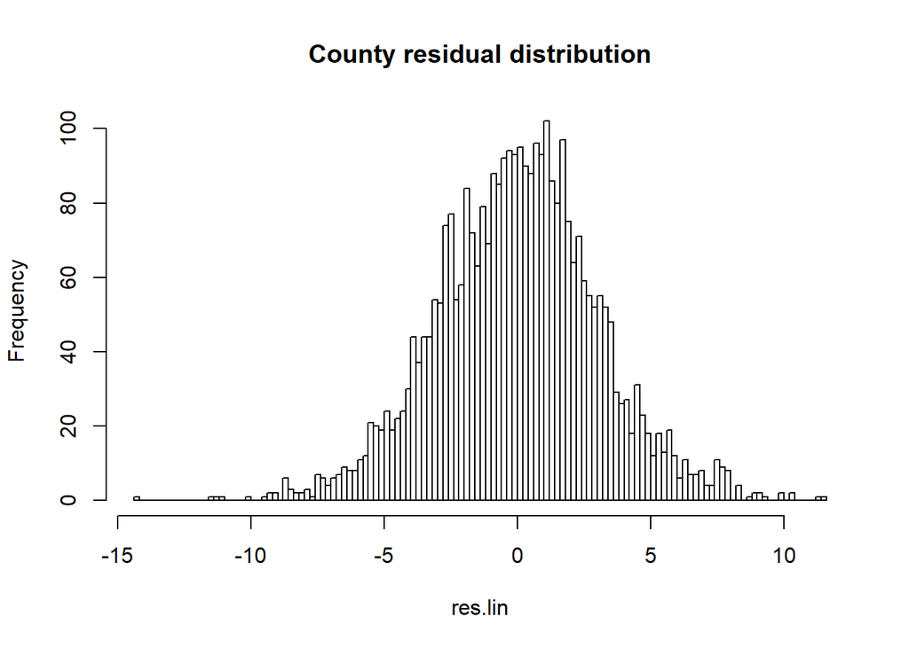

### Model diagnostics

How about general model diagnostics:

```r
modd$DIC
```

```
## [1] 5636.745
```

```r
modd$CPO
```

```
## [1] -2837.04
```

```r
modd$MSE
```

```
## [1] 0.2564192
```

```r
modd$R2
```

```
## [1] 0.6874466
```

The probability integral transform (PIT) is another leave-one-out-cross-validation check that evaluates the predictive performance of the model where a Uniform distribution of PIT means the predictive distribution matches well with the data.

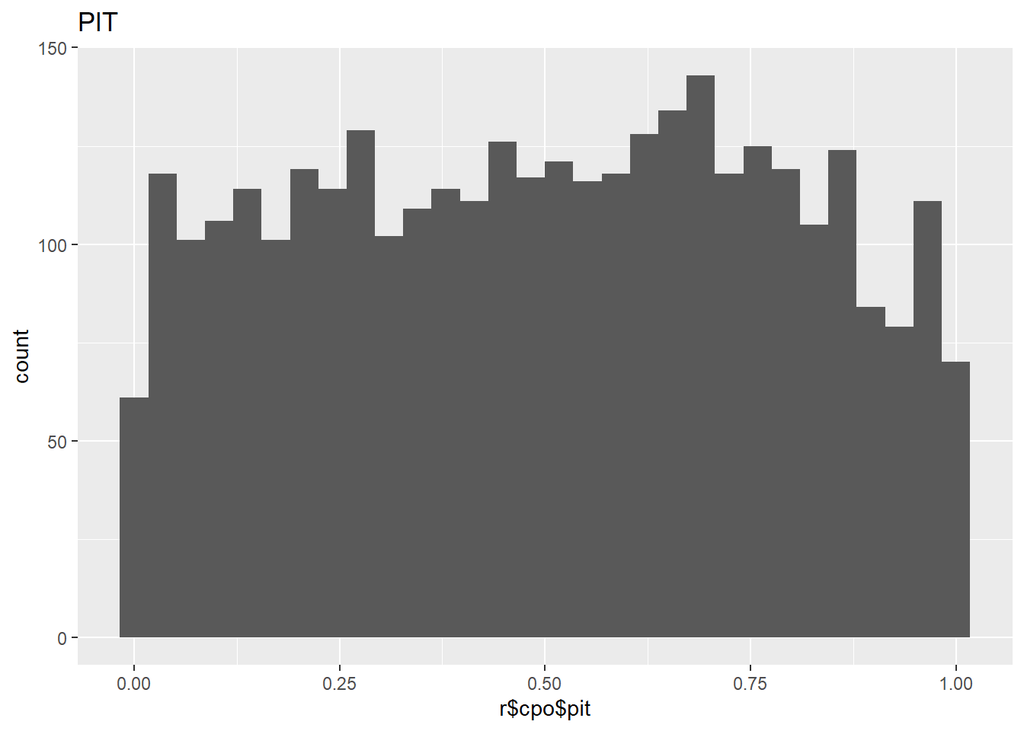

The second PPC provides a histogram of the posterior predictive p-value which estimates the probability of predicting a value more extreme than the observed value, where values near 0 and 1 indicate that the model does not adequately account for the tails of the observed distribution.

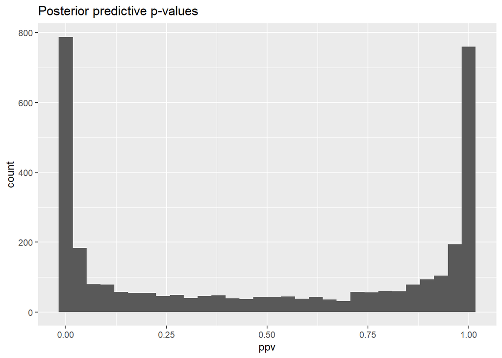

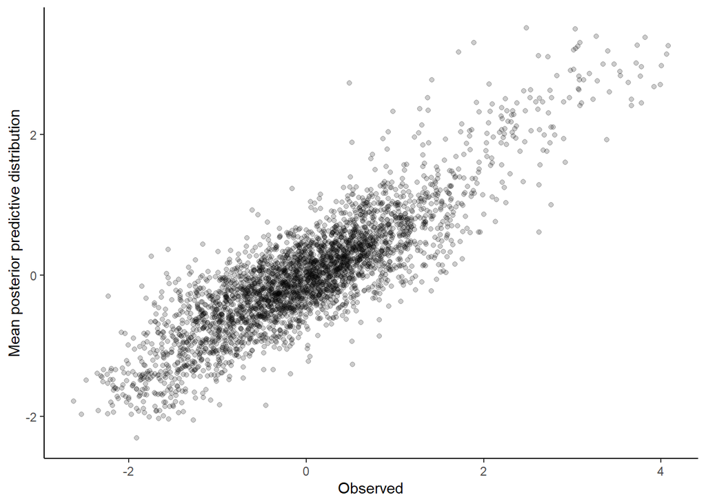

### FRR bright spots

#### First with “county effects” as u + v

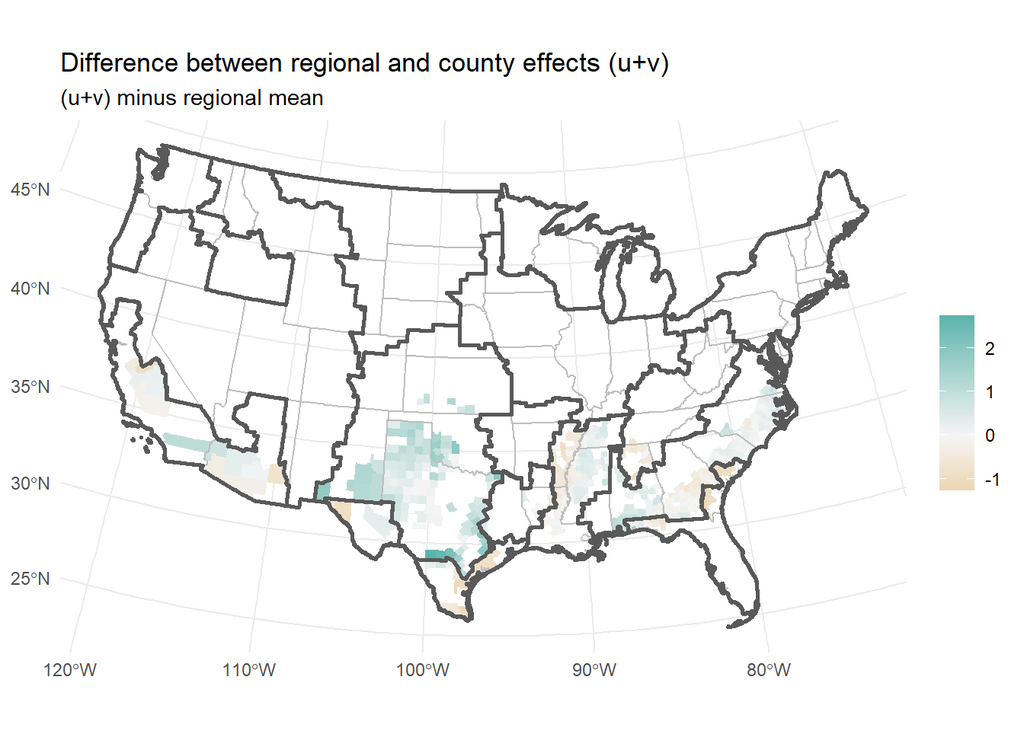

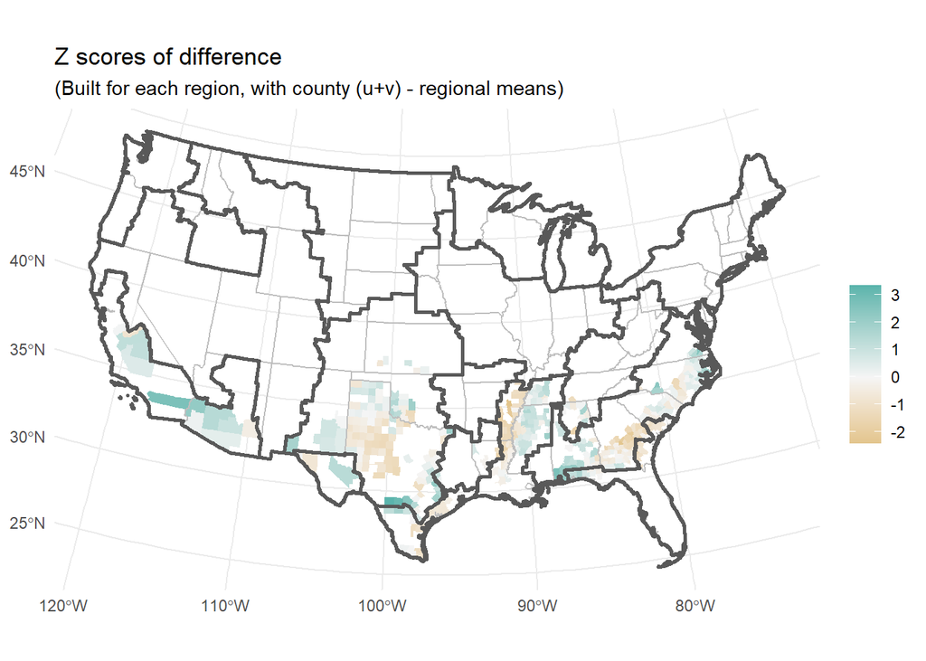

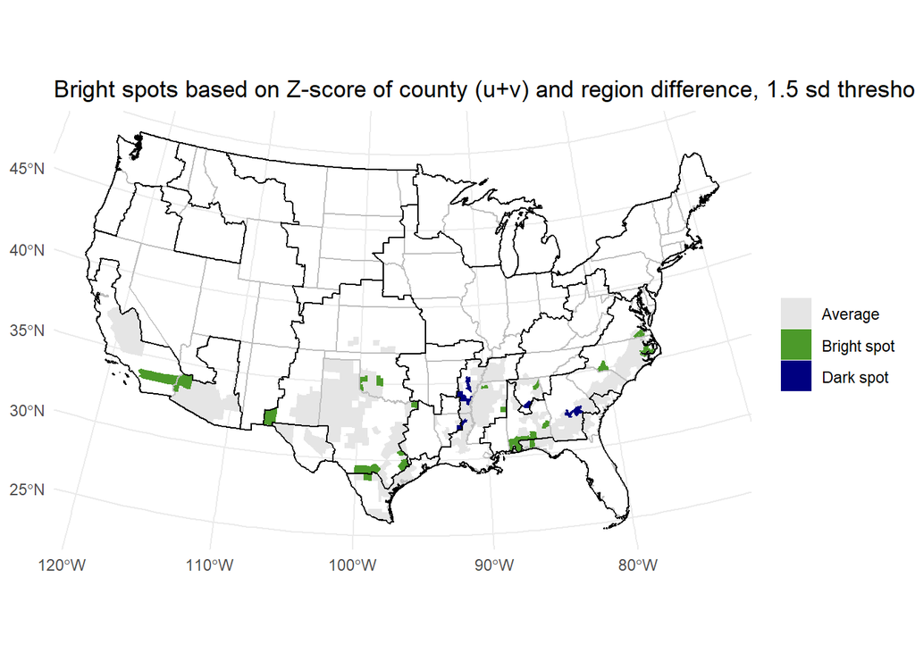

#### Now with “county effects” as v only

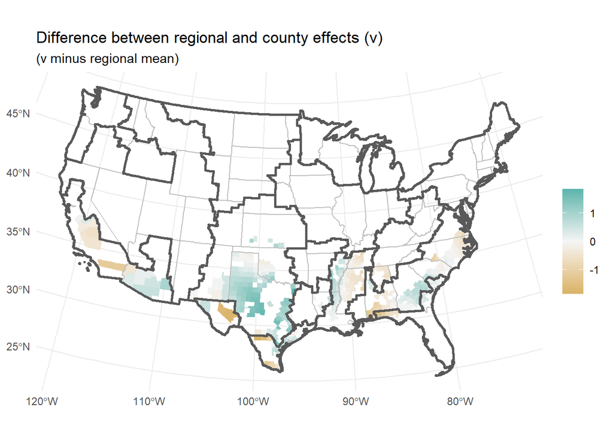

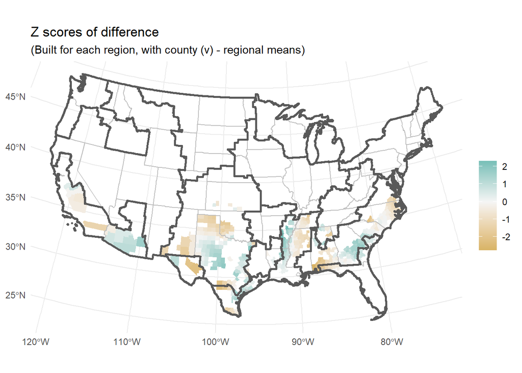

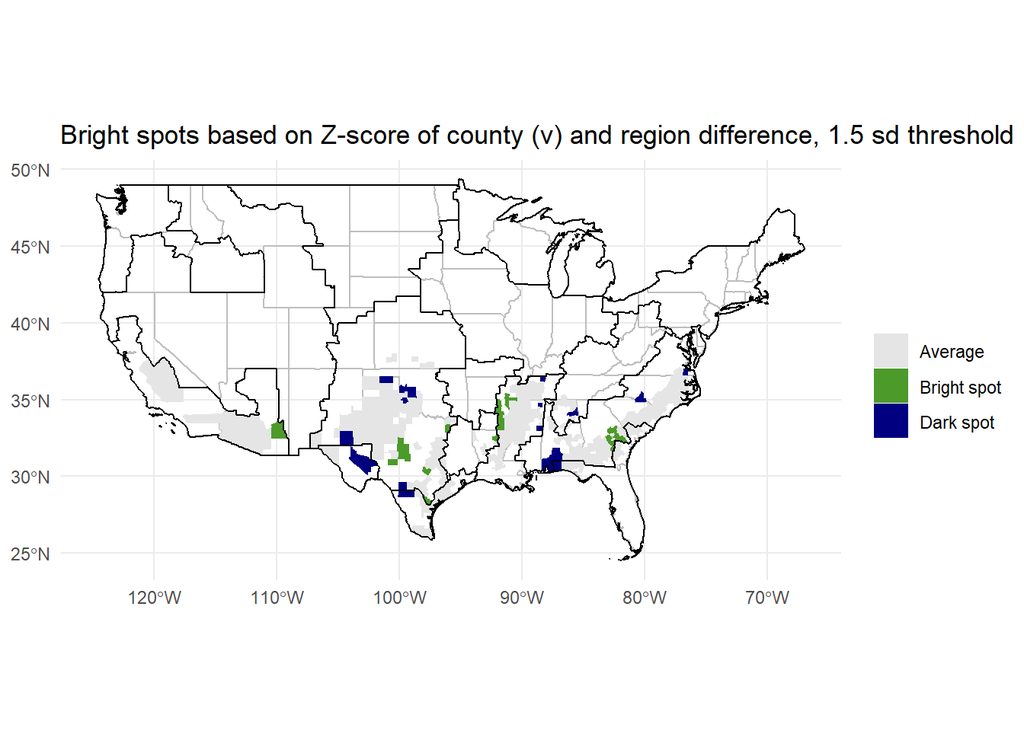